# Análise da Base de Dados Notas

#### **Estudo gráfico da relação entre as variáveis qualitativas e quantitativas**

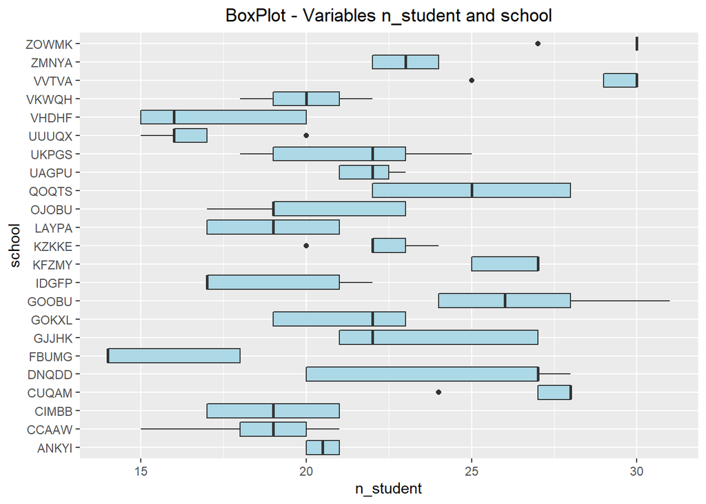

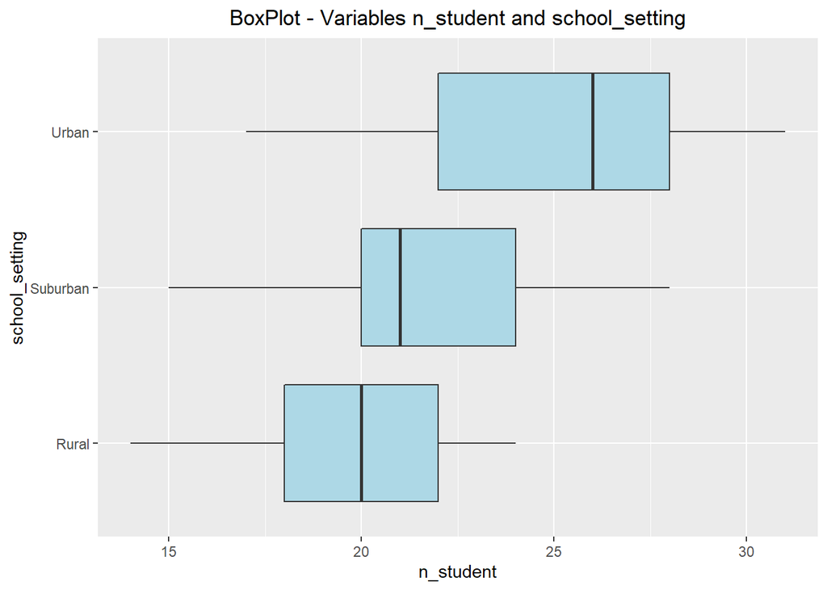

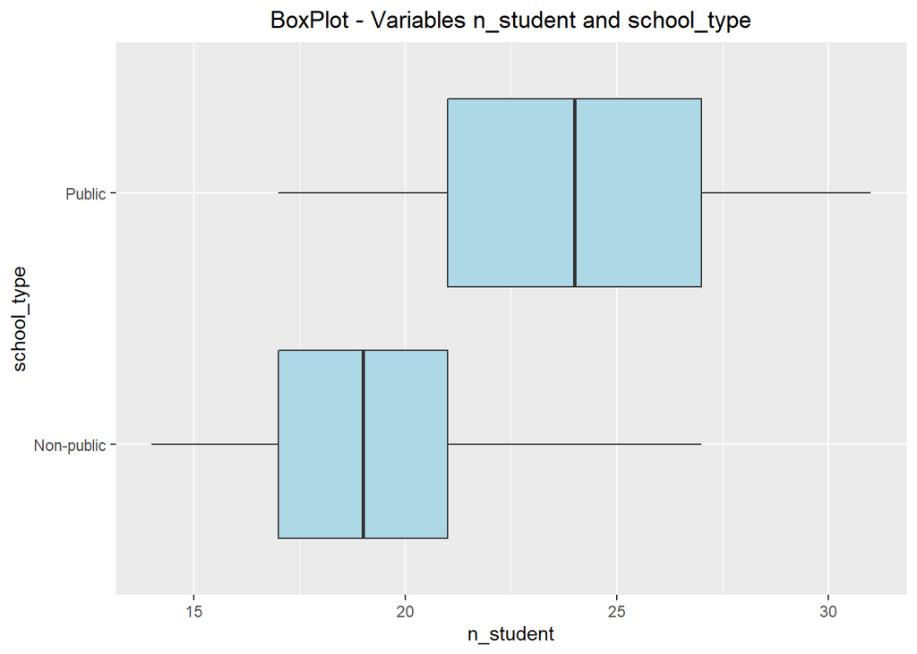

[figure not shown]

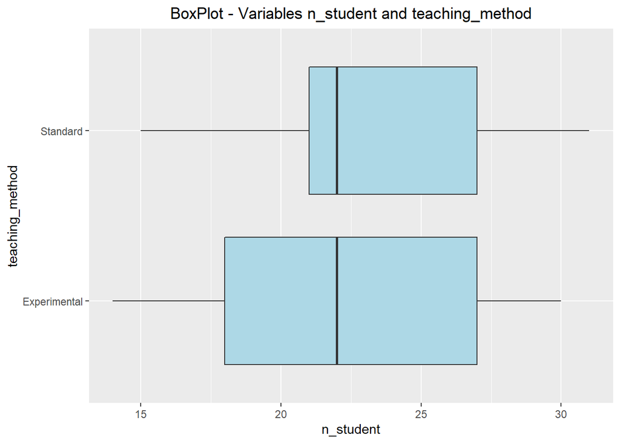

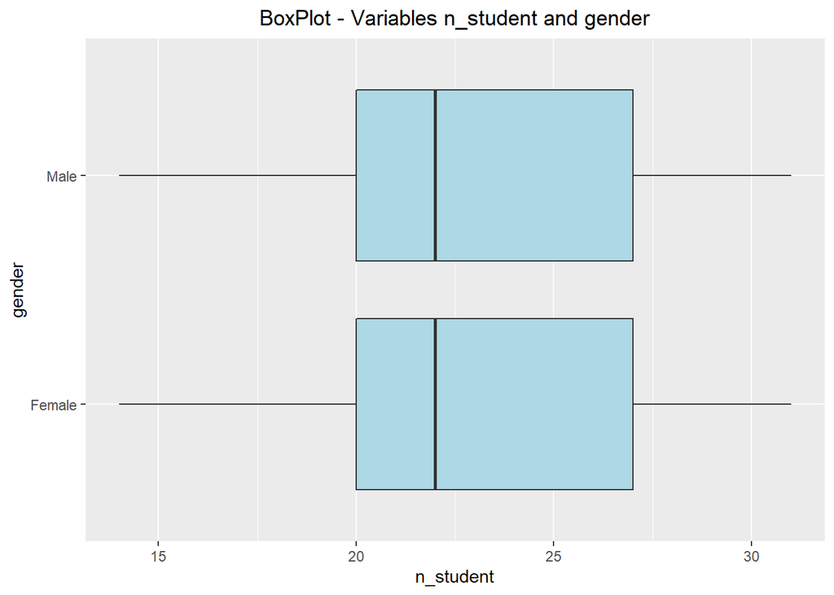

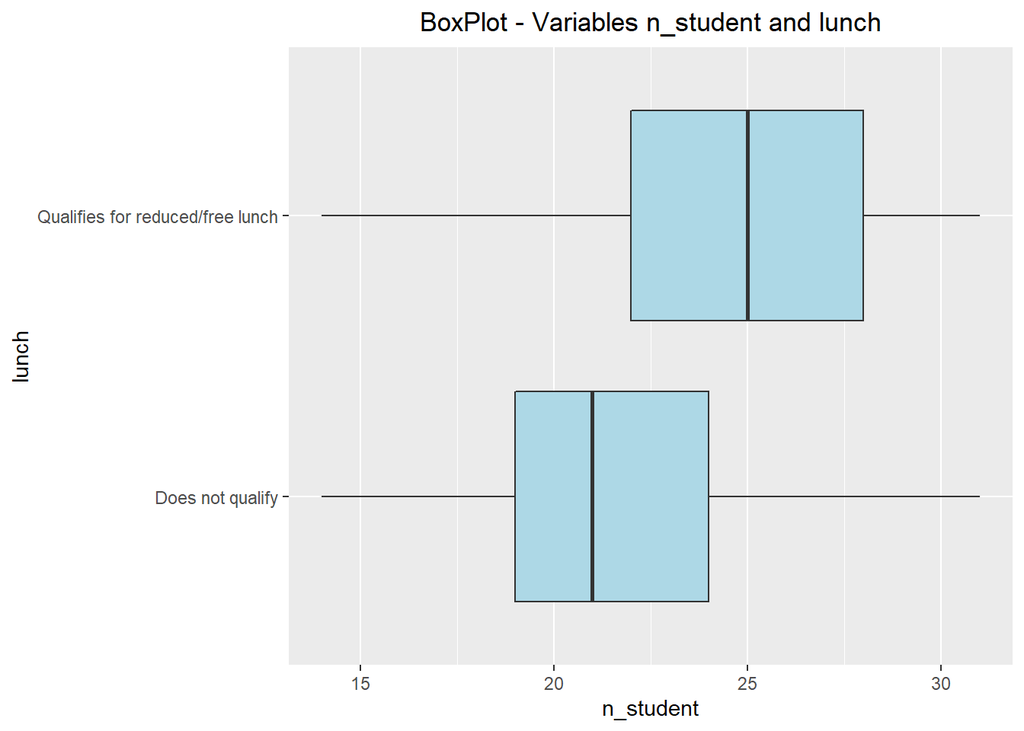

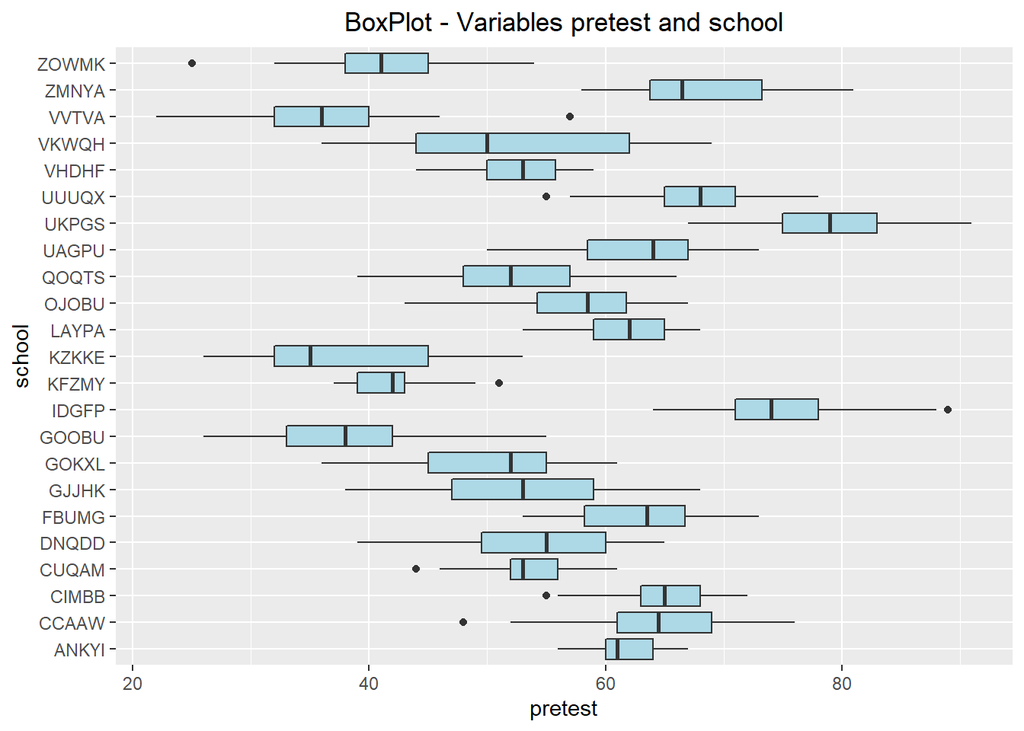

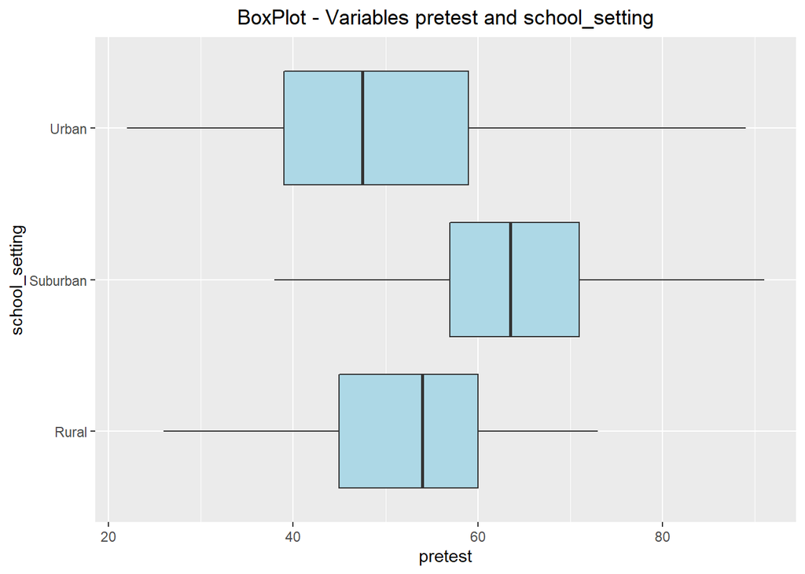

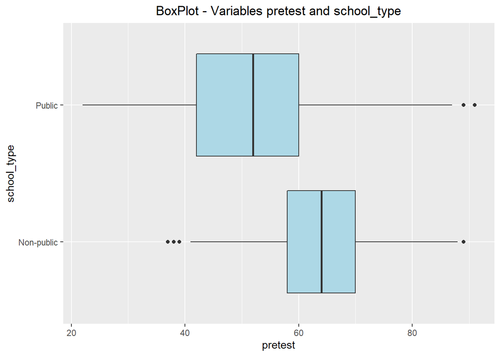

[figure not shown]

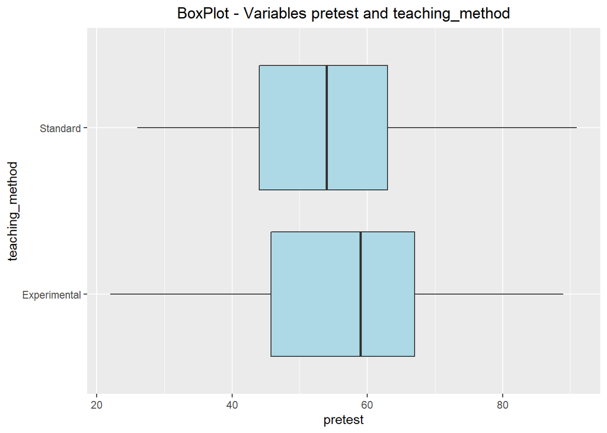

[9 more figures not shown]

Uma escola específica apresenta desempenho superior a outra ?  
A zona que a escola está localizada influencia no resultado (rural, urbana e suburbana) ?  
Escolas públicas possuem desempenho diferente das escolas particulares ?  
Meninos e meninas possuem desempenho diferente ?  
A metodologia de ensino influencia no desempenho do alun o ?  
Um aluno que recebe alimentação tem desempenho diferente de um que não rece be ?  
Os alunos tendem a manter o mesmo desempenho nos pre-teste e no pós-te ste ?

23 escolas